# Risk Factor Analysis

## Outcome Variable

**Outcome Variable:** stunted

## Predictor Variables

**Intervention Variable:** mbmi

**Adjustment Set:**

unadjusted

## Stratifying Variables

The analysis was stratified on these variable(s):

- agecat
- studyid
- country

## Data Summary

| agecat | studyid | country | mbmi | stunted | n_cell | n |
| --- | --- | --- | --- | --- | --- | --- |
| Birth | JiVitA-3 | BANGLADESH | Normal weight | 0 | 9101 | 22355 |
| Birth | JiVitA-3 | BANGLADESH | Normal weight | 1 | 4619 | 22355 |
| Birth | JiVitA-3 | BANGLADESH | Underweight | 0 | 5903 | 22355 |
| Birth | JiVitA-3 | BANGLADESH | Underweight | 1 | 2732 | 22355 |
| Birth | MAL-ED | BANGLADESH | Normal weight | 0 | 159 | 222 |
| Birth | MAL-ED | BANGLADESH | Normal weight | 1 | 35 | 222 |
| Birth | MAL-ED | BANGLADESH | Underweight | 0 | 23 | 222 |
| Birth | MAL-ED | BANGLADESH | Underweight | 1 | 5 | 222 |
| Birth | MAL-ED | BRAZIL | Normal weight | 0 | 52 | 64 |
| Birth | MAL-ED | BRAZIL | Normal weight | 1 | 7 | 64 |
| Birth | MAL-ED | BRAZIL | Underweight | 0 | 3 | 64 |
| Birth | MAL-ED | BRAZIL | Underweight | 1 | 2 | 64 |
| Birth | MAL-ED | INDIA | Normal weight | 0 | 27 | 43 |
| Birth | MAL-ED | INDIA | Normal weight | 1 | 8 | 43 |
| Birth | MAL-ED | INDIA | Underweight | 0 | 7 | 43 |
| Birth | MAL-ED | INDIA | Underweight | 1 | 1 | 43 |
| Birth | MAL-ED | NEPAL | Normal weight | 0 | 25 | 27 |
| Birth | MAL-ED | NEPAL | Normal weight | 1 | 2 | 27 |
| Birth | MAL-ED | NEPAL | Underweight | 0 | 0 | 27 |
| Birth | MAL-ED | NEPAL | Underweight | 1 | 0 | 27 |
| Birth | MAL-ED | PERU | Normal weight | 0 | 197 | 226 |
| Birth | MAL-ED | PERU | Normal weight | 1 | 24 | 226 |
| Birth | MAL-ED | PERU | Underweight | 0 | 3 | 226 |
| Birth | MAL-ED | PERU | Underweight | 1 | 2 | 226 |
| Birth | MAL-ED | SOUTH AFRICA | Normal weight | 0 | 89 | 101 |
| Birth | MAL-ED | SOUTH AFRICA | Normal weight | 1 | 9 | 101 |
| Birth | MAL-ED | SOUTH AFRICA | Underweight | 0 | 3 | 101 |
| Birth | MAL-ED | SOUTH AFRICA | Underweight | 1 | 0 | 101 |
| Birth | MAL-ED | TANZANIA, UNITED REPUBLIC OF | Normal weight | 0 | 96 | 122 |
| Birth | MAL-ED | TANZANIA, UNITED REPUBLIC OF | Normal weight | 1 | 19 | 122 |

[output cut: 150 more lines]

The following strata were considered:

- agecat: 24 months, studyid: JiVitA-3, country: BANGLADESH
- agecat: 24 months, studyid: LCNI-5, country: MALAWI
- agecat: 24 months, studyid: MAL-ED, country: BANGLADESH
- agecat: 24 months, studyid: MAL-ED, country: BRAZIL
- agecat: 24 months, studyid: MAL-ED, country: INDIA
- agecat: 24 months, studyid: MAL-ED, country: NEPAL
- agecat: 24 months, studyid: MAL-ED, country: PERU
- agecat: 24 months, studyid: MAL-ED, country: SOUTH AFRICA
- agecat: 24 months, studyid: MAL-ED, country: TANZANIA, UNITED REPUBLIC OF
- agecat: 24 months, studyid: NIH-Birth, country: BANGLADESH
- agecat: 24 months, studyid: NIH-Crypto, country: BANGLADESH
- agecat: 24 months, studyid: PROBIT, country: BELARUS
- agecat: 24 months, studyid: PROVIDE, country: BANGLADESH
- agecat: 24 months, studyid: TanzaniaChild2, country: TANZANIA, UNITED REPUBLIC OF
- agecat: 24 months, studyid: ZVITAMBO, country: ZIMBABWE
- agecat: 6 months, studyid: JiVitA-3, country: BANGLADESH
- agecat: 6 months, studyid: LCNI-5, country: MALAWI
- agecat: 6 months, studyid: MAL-ED, country: BANGLADESH
- agecat: 6 months, studyid: MAL-ED, country: BRAZIL
- agecat: 6 months, studyid: MAL-ED, country: INDIA
- agecat: 6 months, studyid: MAL-ED, country: NEPAL
- agecat: 6 months, studyid: MAL-ED, country: PERU
- agecat: 6 months, studyid: MAL-ED, country: SOUTH AFRICA
- agecat: 6 months, studyid: MAL-ED, country: TANZANIA, UNITED REPUBLIC OF
- agecat: 6 months, studyid: NIH-Birth, country: BANGLADESH
- agecat: 6 months, studyid: NIH-Crypto, country: BANGLADESH
- agecat: 6 months, studyid: PROBIT, country: BELARUS
- agecat: 6 months, studyid: PROVIDE, country: BANGLADESH
- agecat: 6 months, studyid: SAS-CompFeed, country: INDIA
- agecat: 6 months, studyid: TanzaniaChild2, country: TANZANIA, UNITED REPUBLIC OF
- agecat: 6 months, studyid: ZVITAMBO, country: ZIMBABWE
- agecat: Birth, studyid: JiVitA-3, country: BANGLADESH
- agecat: Birth, studyid: MAL-ED, country: BANGLADESH
- agecat: Birth, studyid: MAL-ED, country: BRAZIL
- agecat: Birth, studyid: MAL-ED, country: INDIA
- agecat: Birth, studyid: MAL-ED, country: NEPAL
- agecat: Birth, studyid: MAL-ED, country: PERU
- agecat: Birth, studyid: MAL-ED, country: SOUTH AFRICA
- agecat: Birth, studyid: MAL-ED, country: TANZANIA, UNITED REPUBLIC OF
- agecat: Birth, studyid: NIH-Birth, country: BANGLADESH
- agecat: Birth, studyid: NIH-Crypto, country: BANGLADESH
- agecat: Birth, studyid: PROBIT, country: BELARUS
- agecat: Birth, studyid: PROVIDE, country: BANGLADESH
- agecat: Birth, studyid: SAS-CompFeed, country: INDIA
- agecat: Birth, studyid: ZVITAMBO, country: ZIMBABWE

### Dropped Strata

Some strata were dropped due to rare outcomes:

- agecat: Birth, studyid: MAL-ED, country: BRAZIL
- agecat: Birth, studyid: MAL-ED, country: INDIA
- agecat: Birth, studyid: MAL-ED, country: NEPAL
- agecat: Birth, studyid: MAL-ED, country: PERU
- agecat: Birth, studyid: MAL-ED, country: SOUTH AFRICA
- agecat: Birth, studyid: MAL-ED, country: TANZANIA, UNITED REPUBLIC OF
- agecat: Birth, studyid: PROBIT, country: BELARUS
- agecat: 6 months, studyid: MAL-ED, country: BRAZIL
- agecat: 6 months, studyid: MAL-ED, country: NEPAL
- agecat: 6 months, studyid: MAL-ED, country: PERU
- agecat: 6 months, studyid: MAL-ED, country: SOUTH AFRICA
- agecat: 6 months, studyid: MAL-ED, country: TANZANIA, UNITED REPUBLIC OF
- agecat: 6 months, studyid: TanzaniaChild2, country: TANZANIA, UNITED REPUBLIC OF
- agecat: 24 months, studyid: MAL-ED, country: BRAZIL
- agecat: 24 months, studyid: MAL-ED, country: NEPAL
- agecat: 24 months, studyid: MAL-ED, country: PERU
- agecat: 24 months, studyid: MAL-ED, country: SOUTH AFRICA
- agecat: 24 months, studyid: MAL-ED, country: TANZANIA, UNITED REPUBLIC OF
- agecat: 24 months, studyid: TanzaniaChild2, country: TANZANIA, UNITED REPUBLIC OF

## Methods Detail

We’re interested in the causal parameters $E[Y_a]$ for all values of $a \in \mathcal{A}$. These parameters represent the mean outcome if, possibly contrary to fact, we intervened to set all units to have $A=a$. Under the randomization and positivity assumptions, these are identified by the statistical parameters $\psi_a=E_W[E_{Y|A,W}(Y|A=a,W)]$. In addition, we’re interested in the mean of $Y$, $E[Y]$ under no intervention (the observed mean). We will estimate these parameters by using SuperLearner to fit the relevant likelihood factors – $E_{Y|A,W}(Y|A=a,W)$ and $p(A=a|W)$, and then updating our likelihood fit using a joint TMLE.

For unadjusted analyses ($W=\{\}$), initial likelihoods were estimated using Lrnr_glm to estimate the simple $E(Y|A)$ and Lrnr_mean to estimate $p(A)$. For adjusted analyses, a small library containing Lrnr_glmnet, Lrnr_xgboost, and Lrnr_mean was used.

Having estimated these parameters, we will then use the delta method to estimate relative risks and attributable risks relative to a prespecified baseline level of $A$.

# Results Detail

## Results Plots

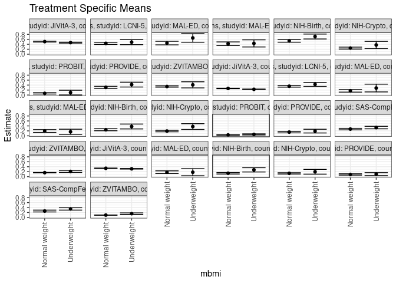

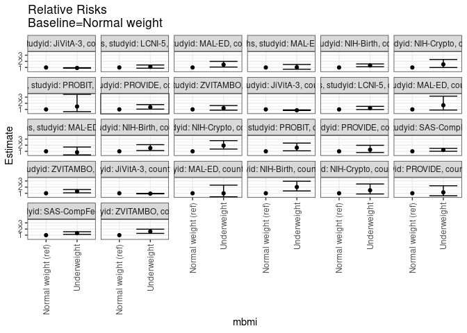

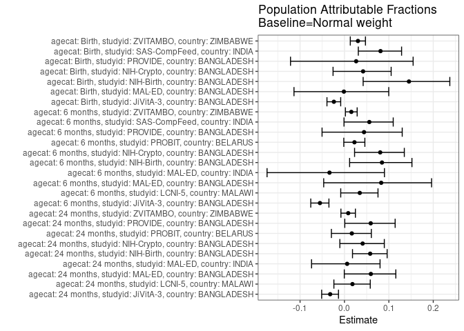

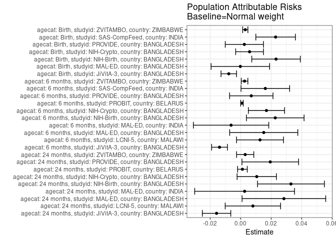

## Results Table

### Parameter: TSM

| agecat | studyid | country | intervention_level | baseline_level | estimate | ci_lower | ci_upper |
| --- | --- | --- | --- | --- | --- | --- | --- |
| Birth | JiVitA-3 | BANGLADESH | Normal weight | NA | 0.3366618 | 0.3276095 | 0.3457142 |
| Birth | JiVitA-3 | BANGLADESH | Underweight | NA | 0.3163868 | 0.3055832 | 0.3271904 |
| Birth | MAL-ED | BANGLADESH | Normal weight | NA | 0.1804124 | 0.1261800 | 0.2346447 |
| Birth | MAL-ED | BANGLADESH | Underweight | NA | 0.1785714 | 0.0363908 | 0.3207520 |
| Birth | NIH-Birth | BANGLADESH | Normal weight | NA | 0.1363636 | 0.1064379 | 0.1662894 |
| Birth | NIH-Birth | BANGLADESH | Underweight | NA | 0.2745098 | 0.1878335 | 0.3611861 |
| Birth | NIH-Crypto | BANGLADESH | Normal weight | NA | 0.1327300 | 0.1068865 | 0.1585735 |
| Birth | NIH-Crypto | BANGLADESH | Underweight | NA | 0.1969697 | 0.1009545 | 0.2929849 |
| Birth | PROVIDE | BANGLADESH | Normal weight | NA | 0.0885167 | 0.0612604 | 0.1157731 |
| Birth | PROVIDE | BANGLADESH | Underweight | NA | 0.1010101 | 0.0415931 | 0.1604271 |
| Birth | SAS-CompFeed | INDIA | Normal weight | NA | 0.2590361 | 0.2219477 | 0.2961246 |
| Birth | SAS-CompFeed | INDIA | Underweight | NA | 0.3442623 | 0.2970613 | 0.3914633 |
| Birth | ZVITAMBO | ZIMBABWE | Normal weight | NA | 0.0959398 | 0.0899090 | 0.1019705 |
| Birth | ZVITAMBO | ZIMBABWE | Underweight | NA | 0.1529412 | 0.1217016 | 0.1841807 |
| 6 months | JiVitA-3 | BANGLADESH | Normal weight | NA | 0.2654447 | 0.2552639 | 0.2756255 |
| 6 months | JiVitA-3 | BANGLADESH | Underweight | NA | 0.2293379 | 0.2185183 | 0.2401574 |
| 6 months | LCNI-5 | MALAWI | Normal weight | NA | 0.3545586 | 0.3188690 | 0.3902482 |
| 6 months | LCNI-5 | MALAWI | Underweight | NA | 0.4275862 | 0.3470130 | 0.5081595 |
| 6 months | MAL-ED | BANGLADESH | Normal weight | NA | 0.1674641 | 0.1167370 | 0.2181912 |
| 6 months | MAL-ED | BANGLADESH | Underweight | NA | 0.2812500 | 0.1251470 | 0.4373530 |
| 6 months | MAL-ED | INDIA | Normal weight | NA | 0.1935484 | 0.1366498 | 0.2504470 |
| 6 months | MAL-ED | INDIA | Underweight | NA | 0.1632653 | 0.0595562 | 0.2669744 |
| 6 months | NIH-Birth | BANGLADESH | Normal weight | NA | 0.2454955 | 0.2054260 | 0.2855650 |
| 6 months | NIH-Birth | BANGLADESH | Underweight | NA | 0.3763441 | 0.2777896 | 0.4748986 |
| 6 months | NIH-Crypto | BANGLADESH | Normal weight | NA | 0.1929012 | 0.1624997 | 0.2233028 |
| 6 months | NIH-Crypto | BANGLADESH | Underweight | NA | 0.3731343 | 0.2572474 | 0.4890213 |
| 6 months | PROBIT | BELARUS | Normal weight | NA | 0.0360224 | 0.0267808 | 0.0452639 |
| 6 months | PROBIT | BELARUS | Underweight | NA | 0.0574257 | 0.0355151 | 0.0793364 |
| 6 months | PROVIDE | BANGLADESH | Normal weight | NA | 0.1506024 | 0.1191637 | 0.1820412 |
| 6 months | PROVIDE | BANGLADESH | Underweight | NA | 0.1904762 | 0.1153054 | 0.2656470 |
| 6 months | SAS-CompFeed | INDIA | Normal weight | NA | 0.2721239 | 0.2420905 | 0.3021573 |
| 6 months | SAS-CompFeed | INDIA | Underweight | NA | 0.3333333 | 0.2829434 | 0.3837232 |
| 6 months | ZVITAMBO | ZIMBABWE | Normal weight | NA | 0.1605944 | 0.1519921 | 0.1691966 |
| 6 months | ZVITAMBO | ZIMBABWE | Underweight | NA | 0.2101064 | 0.1689263 | 0.2512865 |
| 24 months | JiVitA-3 | BANGLADESH | Normal weight | NA | 0.5072793 | 0.4907056 | 0.5238529 |
| 24 months | JiVitA-3 | BANGLADESH | Underweight | NA | 0.4661631 | 0.4469801 | 0.4853462 |
| 24 months | LCNI-5 | MALAWI | Normal weight | NA | 0.4356846 | 0.3913801 | 0.4799892 |
| 24 months | LCNI-5 | MALAWI | Underweight | NA | 0.4842105 | 0.3836294 | 0.5847916 |
| 24 months | MAL-ED | BANGLADESH | Normal weight | NA | 0.4480874 | 0.3758661 | 0.5203088 |
| 24 months | MAL-ED | BANGLADESH | Underweight | NA | 0.6551724 | 0.4817702 | 0.8285746 |
| 24 months | MAL-ED | INDIA | Normal weight | NA | 0.4222222 | 0.3499077 | 0.4945368 |
| 24 months | MAL-ED | INDIA | Underweight | NA | 0.4347826 | 0.2912086 | 0.5783567 |
| 24 months | NIH-Birth | BANGLADESH | Normal weight | NA | 0.5358166 | 0.4834331 | 0.5882002 |
| 24 months | NIH-Birth | BANGLADESH | Underweight | NA | 0.7125000 | 0.6132064 | 0.8117936 |
| 24 months | NIH-Crypto | BANGLADESH | Normal weight | NA | 0.2462845 | 0.2073367 | 0.2852323 |
| 24 months | NIH-Crypto | BANGLADESH | Underweight | NA | 0.3720930 | 0.2274791 | 0.5167070 |
| 24 months | PROBIT | BELARUS | Normal weight | NA | 0.0667875 | 0.0405503 | 0.0930246 |
| 24 months | PROBIT | BELARUS | Underweight | NA | 0.0985915 | 0.0031890 | 0.1939941 |
| 24 months | PROVIDE | BANGLADESH | Normal weight | NA | 0.3081761 | 0.2667034 | 0.3496488 |
| 24 months | PROVIDE | BANGLADESH | Underweight | NA | 0.4200000 | 0.3231804 | 0.5168196 |
| 24 months | ZVITAMBO | ZIMBABWE | Normal weight | NA | 0.3437500 | 0.3180404 | 0.3694596 |
| 24 months | ZVITAMBO | ZIMBABWE | Underweight | NA | 0.4098361 | 0.2863742 | 0.5332979 |

### Parameter: E(Y)

| agecat | studyid | country | intervention_level | baseline_level | estimate | ci_lower | ci_upper |
| --- | --- | --- | --- | --- | --- | --- | --- |
| Birth | JiVitA-3 | BANGLADESH | NA | NA | 0.3288302 | 0.3214550 | 0.3362055 |
| Birth | MAL-ED | BANGLADESH | NA | NA | 0.1801802 | 0.1295086 | 0.2308518 |
| Birth | NIH-Birth | BANGLADESH | NA | NA | 0.1595395 | 0.1304091 | 0.1886699 |
| Birth | NIH-Crypto | BANGLADESH | NA | NA | 0.1385460 | 0.1134505 | 0.1636414 |
| Birth | PROVIDE | BANGLADESH | NA | NA | 0.0909091 | 0.0661046 | 0.1157136 |
| Birth | SAS-CompFeed | INDIA | NA | NA | 0.2819383 | 0.2495848 | 0.3142918 |
| Birth | ZVITAMBO | ZIMBABWE | NA | NA | 0.0989454 | 0.0929945 | 0.1048964 |
| 6 months | JiVitA-3 | BANGLADESH | NA | NA | 0.2515513 | 0.2434364 | 0.2596662 |
| 6 months | LCNI-5 | MALAWI | NA | NA | 0.3672249 | 0.3345288 | 0.3999210 |
| 6 months | MAL-ED | BANGLADESH | NA | NA | 0.1825726 | 0.1336978 | 0.2314474 |
| 6 months | MAL-ED | INDIA | NA | NA | 0.1872340 | 0.1372518 | 0.2372162 |
| 6 months | NIH-Birth | BANGLADESH | NA | NA | 0.2681564 | 0.2306532 | 0.3056597 |
| 6 months | NIH-Crypto | BANGLADESH | NA | NA | 0.2097902 | 0.1799252 | 0.2396552 |
| 6 months | PROBIT | BELARUS | NA | NA | 0.0368522 | 0.0276927 | 0.0460117 |
| 6 months | PROVIDE | BANGLADESH | NA | NA | 0.1575456 | 0.1284434 | 0.1866478 |
| 6 months | SAS-CompFeed | INDIA | NA | NA | 0.2882736 | 0.2624662 | 0.3140810 |
| 6 months | ZVITAMBO | ZIMBABWE | NA | NA | 0.1631186 | 0.1546857 | 0.1715516 |
| 24 months | JiVitA-3 | BANGLADESH | NA | NA | 0.4914525 | 0.4783104 | 0.5045946 |
| 24 months | LCNI-5 | MALAWI | NA | NA | 0.4436742 | 0.4031015 | 0.4842468 |
| 24 months | MAL-ED | BANGLADESH | NA | NA | 0.4764151 | 0.4090254 | 0.5438047 |
| 24 months | MAL-ED | INDIA | NA | NA | 0.4247788 | 0.3601902 | 0.4893673 |
| 24 months | NIH-Birth | BANGLADESH | NA | NA | 0.5687646 | 0.5218455 | 0.6156837 |
| 24 months | NIH-Crypto | BANGLADESH | NA | NA | 0.2568093 | 0.2190047 | 0.2946140 |
| 24 months | PROBIT | BELARUS | NA | NA | 0.0679151 | 0.0407521 | 0.0950781 |
| 24 months | PROVIDE | BANGLADESH | NA | NA | 0.3275563 | 0.2892291 | 0.3658836 |
| 24 months | ZVITAMBO | ZIMBABWE | NA | NA | 0.3466861 | 0.3215035 | 0.3718687 |

### Parameter: RR

| agecat | studyid | country | intervention_level | baseline_level | estimate | ci_lower | ci_upper |
| --- | --- | --- | --- | --- | --- | --- | --- |
| Birth | JiVitA-3 | BANGLADESH | Normal weight | Normal weight | 1.0000000 | 1.0000000 | 1.0000000 |
| Birth | JiVitA-3 | BANGLADESH | Underweight | Normal weight | 0.9397763 | 0.9023899 | 0.9787117 |
| Birth | MAL-ED | BANGLADESH | Normal weight | Normal weight | 1.0000000 | 1.0000000 | 1.0000000 |
| Birth | MAL-ED | BANGLADESH | Underweight | Normal weight | 0.9897959 | 0.4226026 | 2.3182439 |
| Birth | NIH-Birth | BANGLADESH | Normal weight | Normal weight | 1.0000000 | 1.0000000 | 1.0000000 |
| Birth | NIH-Birth | BANGLADESH | Underweight | Normal weight | 2.0130719 | 1.3704490 | 2.9570298 |
| Birth | NIH-Crypto | BANGLADESH | Normal weight | Normal weight | 1.0000000 | 1.0000000 | 1.0000000 |
| Birth | NIH-Crypto | BANGLADESH | Underweight | Normal weight | 1.4839876 | 0.8779405 | 2.5083924 |
| Birth | PROVIDE | BANGLADESH | Normal weight | Normal weight | 1.0000000 | 1.0000000 | 1.0000000 |
| Birth | PROVIDE | BANGLADESH | Underweight | Normal weight | 1.1411411 | 0.5874754 | 2.2166086 |
| Birth | SAS-CompFeed | INDIA | Normal weight | Normal weight | 1.0000000 | 1.0000000 | 1.0000000 |
| Birth | SAS-CompFeed | INDIA | Underweight | Normal weight | 1.3290126 | 1.1322047 | 1.5600310 |
| Birth | ZVITAMBO | ZIMBABWE | Normal weight | Normal weight | 1.0000000 | 1.0000000 | 1.0000000 |
| Birth | ZVITAMBO | ZIMBABWE | Underweight | Normal weight | 1.5941377 | 1.2873950 | 1.9739669 |
| 6 months | JiVitA-3 | BANGLADESH | Normal weight | Normal weight | 1.0000000 | 1.0000000 | 1.0000000 |
| 6 months | JiVitA-3 | BANGLADESH | Underweight | Normal weight | 0.8639762 | 0.8176464 | 0.9129311 |
| 6 months | LCNI-5 | MALAWI | Normal weight | Normal weight | 1.0000000 | 1.0000000 | 1.0000000 |
| 6 months | LCNI-5 | MALAWI | Underweight | Normal weight | 1.2059676 | 0.9739891 | 1.4931973 |
| 6 months | MAL-ED | BANGLADESH | Normal weight | Normal weight | 1.0000000 | 1.0000000 | 1.0000000 |
| 6 months | MAL-ED | BANGLADESH | Underweight | Normal weight | 1.6794643 | 0.8924037 | 3.1606777 |
| 6 months | MAL-ED | INDIA | Normal weight | Normal weight | 1.0000000 | 1.0000000 | 1.0000000 |
| 6 months | MAL-ED | INDIA | Underweight | Normal weight | 0.8435374 | 0.4189110 | 1.6985838 |
| 6 months | NIH-Birth | BANGLADESH | Normal weight | Normal weight | 1.0000000 | 1.0000000 | 1.0000000 |
| 6 months | NIH-Birth | BANGLADESH | Underweight | Normal weight | 1.5329979 | 1.1259769 | 2.0871500 |
| 6 months | NIH-Crypto | BANGLADESH | Normal weight | Normal weight | 1.0000000 | 1.0000000 | 1.0000000 |
| 6 months | NIH-Crypto | BANGLADESH | Underweight | Normal weight | 1.9343284 | 1.3654499 | 2.7402148 |
| 6 months | PROBIT | BELARUS | Normal weight | Normal weight | 1.0000000 | 1.0000000 | 1.0000000 |
| 6 months | PROBIT | BELARUS | Underweight | Normal weight | 1.5941692 | 1.0871309 | 2.3376904 |
| 6 months | PROVIDE | BANGLADESH | Normal weight | Normal weight | 1.0000000 | 1.0000000 | 1.0000000 |
| 6 months | PROVIDE | BANGLADESH | Underweight | Normal weight | 1.2647619 | 0.8093101 | 1.9765262 |
| 6 months | SAS-CompFeed | INDIA | Normal weight | Normal weight | 1.0000000 | 1.0000000 | 1.0000000 |
| 6 months | SAS-CompFeed | INDIA | Underweight | Normal weight | 1.2249322 | 1.0091302 | 1.4868834 |
| 6 months | ZVITAMBO | ZIMBABWE | Normal weight | Normal weight | 1.0000000 | 1.0000000 | 1.0000000 |
| 6 months | ZVITAMBO | ZIMBABWE | Underweight | Normal weight | 1.3083048 | 1.0677440 | 1.6030634 |
| 24 months | JiVitA-3 | BANGLADESH | Normal weight | Normal weight | 1.0000000 | 1.0000000 | 1.0000000 |
| 24 months | JiVitA-3 | BANGLADESH | Underweight | Normal weight | 0.9189478 | 0.8740361 | 0.9661672 |
| 24 months | LCNI-5 | MALAWI | Normal weight | Normal weight | 1.0000000 | 1.0000000 | 1.0000000 |
| 24 months | LCNI-5 | MALAWI | Underweight | Normal weight | 1.1113784 | 0.8819005 | 1.4005684 |
| 24 months | MAL-ED | BANGLADESH | Normal weight | Normal weight | 1.0000000 | 1.0000000 | 1.0000000 |
| 24 months | MAL-ED | BANGLADESH | Underweight | Normal weight | 1.4621531 | 1.0725391 | 1.9932995 |
| 24 months | MAL-ED | INDIA | Normal weight | Normal weight | 1.0000000 | 1.0000000 | 1.0000000 |
| 24 months | MAL-ED | INDIA | Underweight | Normal weight | 1.0297483 | 0.7098658 | 1.4937775 |
| 24 months | NIH-Birth | BANGLADESH | Normal weight | Normal weight | 1.0000000 | 1.0000000 | 1.0000000 |
| 24 months | NIH-Birth | BANGLADESH | Underweight | Normal weight | 1.3297460 | 1.1216000 | 1.5765197 |
| 24 months | NIH-Crypto | BANGLADESH | Normal weight | Normal weight | 1.0000000 | 1.0000000 | 1.0000000 |
| 24 months | NIH-Crypto | BANGLADESH | Underweight | Normal weight | 1.5108260 | 0.9930884 | 2.2984813 |
| 24 months | PROBIT | BELARUS | Normal weight | Normal weight | 1.0000000 | 1.0000000 | 1.0000000 |
| 24 months | PROBIT | BELARUS | Underweight | Normal weight | 1.4761983 | 0.6332285 | 3.4413504 |
| 24 months | PROVIDE | BANGLADESH | Normal weight | Normal weight | 1.0000000 | 1.0000000 | 1.0000000 |
| 24 months | PROVIDE | BANGLADESH | Underweight | Normal weight | 1.3628571 | 1.0435769 | 1.7798206 |
| 24 months | ZVITAMBO | ZIMBABWE | Normal weight | Normal weight | 1.0000000 | 1.0000000 | 1.0000000 |
| 24 months | ZVITAMBO | ZIMBABWE | Underweight | Normal weight | 1.1922504 | 0.8741093 | 1.6261822 |

### Parameter: PAR

| agecat | studyid | country | intervention_level | baseline_level | estimate | ci_lower | ci_upper |
| --- | --- | --- | --- | --- | --- | --- | --- |
| Birth | JiVitA-3 | BANGLADESH | Normal weight | NA | -0.0078316 | -0.0129211 | -0.0027420 |
| Birth | MAL-ED | BANGLADESH | Normal weight | NA | -0.0002322 | -0.0194253 | 0.0189609 |
| Birth | NIH-Birth | BANGLADESH | Normal weight | NA | 0.0231758 | 0.0072538 | 0.0390979 |
| Birth | NIH-Crypto | BANGLADESH | Normal weight | NA | 0.0058159 | -0.0032852 | 0.0149171 |
| Birth | PROVIDE | BANGLADESH | Normal weight | NA | 0.0023923 | -0.0101326 | 0.0149173 |
| Birth | SAS-CompFeed | INDIA | Normal weight | NA | 0.0229022 | 0.0099147 | 0.0358896 |
| Birth | ZVITAMBO | ZIMBABWE | Normal weight | NA | 0.0030057 | 0.0013089 | 0.0047024 |
| 6 months | JiVitA-3 | BANGLADESH | Normal weight | NA | -0.0138934 | -0.0190765 | -0.0087103 |
| 6 months | LCNI-5 | MALAWI | Normal weight | NA | 0.0126663 | -0.0027330 | 0.0280655 |
| 6 months | MAL-ED | BANGLADESH | Normal weight | NA | 0.0151085 | -0.0072265 | 0.0374435 |
| 6 months | MAL-ED | INDIA | Normal weight | NA | -0.0063143 | -0.0310298 | 0.0184011 |
| 6 months | NIH-Birth | BANGLADESH | Normal weight | NA | 0.0226609 | 0.0037653 | 0.0415566 |
| 6 months | NIH-Crypto | BANGLADESH | Normal weight | NA | 0.0168890 | 0.0050195 | 0.0287584 |
| 6 months | PROBIT | BELARUS | Normal weight | NA | 0.0008298 | -0.0000089 | 0.0016686 |
| 6 months | PROVIDE | BANGLADESH | Normal weight | NA | 0.0069432 | -0.0072962 | 0.0211826 |
| 6 months | SAS-CompFeed | INDIA | Normal weight | NA | 0.0161497 | 0.0002132 | 0.0320862 |
| 6 months | ZVITAMBO | ZIMBABWE | Normal weight | NA | 0.0025243 | 0.0003651 | 0.0046834 |
| 24 months | JiVitA-3 | BANGLADESH | Normal weight | NA | -0.0158268 | -0.0251517 | -0.0065018 |
| 24 months | LCNI-5 | MALAWI | Normal weight | NA | 0.0079895 | -0.0101656 | 0.0261446 |
| 24 months | MAL-ED | BANGLADESH | Normal weight | NA | 0.0283277 | 0.0008971 | 0.0557582 |
| 24 months | MAL-ED | INDIA | Normal weight | NA | 0.0025565 | -0.0301706 | 0.0352837 |
| 24 months | NIH-Birth | BANGLADESH | Normal weight | NA | 0.0329479 | 0.0110212 | 0.0548747 |
| 24 months | NIH-Crypto | BANGLADESH | Normal weight | NA | 0.0105248 | -0.0023618 | 0.0234115 |
| 24 months | PROBIT | BELARUS | Normal weight | NA | 0.0011276 | -0.0020525 | 0.0043077 |
| 24 months | PROVIDE | BANGLADESH | Normal weight | NA | 0.0193802 | 0.0008014 | 0.0379591 |
| 24 months | ZVITAMBO | ZIMBABWE | Normal weight | NA | 0.0029361 | -0.0027129 | 0.0085851 |

### Parameter: PAF

| agecat | studyid | country | intervention_level | baseline_level | estimate | ci_lower | ci_upper |
| --- | --- | --- | --- | --- | --- | --- | --- |
| Birth | JiVitA-3 | BANGLADESH | Normal weight | NA | -0.0238164 | -0.0394093 | -0.0084575 |
| Birth | MAL-ED | BANGLADESH | Normal weight | NA | -0.0012887 | -0.1136825 | 0.0997623 |
| Birth | NIH-Birth | BANGLADESH | Normal weight | NA | 0.1452671 | 0.0421121 | 0.2373134 |
| Birth | NIH-Crypto | BANGLADESH | Normal weight | NA | 0.0419784 | -0.0256898 | 0.1051823 |
| Birth | PROVIDE | BANGLADESH | Normal weight | NA | 0.0263158 | -0.1215085 | 0.1546556 |
| Birth | SAS-CompFeed | INDIA | Normal weight | NA | 0.0812312 | 0.0312085 | 0.1286709 |
| Birth | ZVITAMBO | ZIMBABWE | Normal weight | NA | 0.0303769 | 0.0131540 | 0.0472992 |
| 6 months | JiVitA-3 | BANGLADESH | Normal weight | NA | -0.0552307 | -0.0758796 | -0.0349782 |
| 6 months | LCNI-5 | MALAWI | Normal weight | NA | 0.0344919 | -0.0083804 | 0.0755414 |
| 6 months | MAL-ED | BANGLADESH | Normal weight | NA | 0.0827534 | -0.0467563 | 0.1962395 |
| 6 months | MAL-ED | INDIA | Normal weight | NA | -0.0337243 | -0.1743434 | 0.0900566 |
| 6 months | NIH-Birth | BANGLADESH | Normal weight | NA | 0.0845064 | 0.0116116 | 0.1520251 |
| 6 months | NIH-Crypto | BANGLADESH | Normal weight | NA | 0.0805041 | 0.0227845 | 0.1348145 |
| 6 months | PROBIT | BELARUS | Normal weight | NA | 0.0225181 | -0.0014932 | 0.0459538 |
| 6 months | PROVIDE | BANGLADESH | Normal weight | NA | 0.0440710 | -0.0504635 | 0.1300981 |
| 6 months | SAS-CompFeed | INDIA | Normal weight | NA | 0.0560222 | -0.0010359 | 0.1098280 |
| 6 months | ZVITAMBO | ZIMBABWE | Normal weight | NA | 0.0154751 | 0.0021640 | 0.0286085 |
| 24 months | JiVitA-3 | BANGLADESH | Normal weight | NA | -0.0322041 | -0.0513199 | -0.0134358 |
| 24 months | LCNI-5 | MALAWI | Normal weight | NA | 0.0180077 | -0.0237964 | 0.0581047 |
| 24 months | MAL-ED | BANGLADESH | Normal weight | NA | 0.0594600 | -0.0003790 | 0.1157197 |
| 24 months | MAL-ED | INDIA | Normal weight | NA | 0.0060185 | -0.0740941 | 0.0801558 |
| 24 months | NIH-Birth | BANGLADESH | Normal weight | NA | 0.0579290 | 0.0181221 | 0.0961221 |
| 24 months | NIH-Crypto | BANGLADESH | Normal weight | NA | 0.0409831 | -0.0104036 | 0.0897564 |
| 24 months | PROBIT | BELARUS | Normal weight | NA | 0.0166036 | -0.0294100 | 0.0605604 |
| 24 months | PROVIDE | BANGLADESH | Normal weight | NA | 0.0591661 | 0.0007394 | 0.1141766 |
| 24 months | ZVITAMBO | ZIMBABWE | Normal weight | NA | 0.0084690 | -0.0079605 | 0.0246307 |